# Untitled4-Copy2

```python
import pandas as pd
import numpy as np
import matplotlib.pyplot as plt
import seaborn as sns
```

**Data Preprocessing**

Firstly, data was uploaded, examined and organized in a way that would be useful for homework requirements and tasks.

```python
file_path = "match_data.csv"
data = pd.read_csv(file_path)
```

```python
print(data.head())
```

```
   fixture_id  halftime         current_time  half_start_datetime  \
0  19172016.0  1st-half  2024-08-09 18:11:36  2024-08-09 18:01:37
1  19172016.0  1st-half  2024-08-09 18:27:30  2024-08-09 18:01:37
2  19172016.0  1st-half  2024-08-09 18:28:25  2024-08-09 18:01:37
3  19172016.0  1st-half  2024-08-09 18:29:32  2024-08-09 18:01:37
4  19172016.0  1st-half  2024-08-09 18:30:37  2024-08-09 18:01:37

  match_start_datetime  minute  second latest_bookmaker_update  suspended  \
0  2024-08-09 18:01:37       9      59     2024-08-09 18:11:28      False
1  2024-08-09 18:01:37      25      53     2024-08-09 18:27:24      False
2  2024-08-09 18:01:37      26      48     2024-08-09 18:28:20      False
3  2024-08-09 18:01:37      27      55     2024-08-09 18:29:28      False
4  2024-08-09 18:01:37      29       0     2024-08-09 18:30:32       True

   stopped  ...  Throwins - home  Total Crosses - away  Total Crosses - home  \
```

[output cut: 21 more lines]

```python
print(data.columns)
```

```
Index(['fixture_id', 'halftime', 'current_time', 'half_start_datetime',
       'match_start_datetime', 'minute', 'second', 'latest_bookmaker_update',
       'suspended', 'stopped',
       ...
       'Throwins - home', 'Total Crosses - away', 'Total Crosses - home',
       'Yellowcards - away', 'Yellowcards - home', 'Yellowred Cards - away',
       'Yellowred Cards - home', 'current_state', 'final_score', 'result'],
      dtype='object', length=106)
```

```python
print(data.describe())
```

```
         fixture_id        minute        second             1             2  \
count  6.394400e+04  63944.000000  63944.000000  63944.000000  63944.000000
mean   1.914800e+07     25.476526     27.695421     18.510137     29.482377
std    1.345825e+04     14.496434     18.289720     64.166275     82.639170
min    1.913445e+07      0.000000      0.000000      1.000000      1.000000
25%    1.913530e+07     13.000000     10.000000      1.330000      1.950000
50%    1.913974e+07     25.000000     27.000000      2.500000      4.000000
75%    1.915513e+07     38.000000     44.000000      5.500000     13.000000
max    1.917212e+07     80.000000     59.000000    501.000000    501.000000

                  X  Accurate Crosses - away  Accurate Crosses - home  \
count  63944.000000             60916.000000             60937.000000
mean       8.698023                 2.010276                 2.631209
std       12.092077                 1.950212                 2.292960
min        1.000000                 0.000000                 0.000000
25%        3.000000                 0.000000                 1.000000
50%        3.750000                 2.000000                 2.000000
75%        7.500000                 3.000000                 4.000000
max       51.000000                12.000000                14.000000

       Assists - away  Assists - home  ...  Tackles - away  Tackles - home  \
count    36010.000000    36013.000000  ...    61984.000000    61995.000000
mean         0.812746        0.901397  ...        8.411122        8.613533
std          0.794087        0.826550  ...        5.695672        5.720836
min          0.000000        0.000000  ...        0.000000        0.000000
25%          0.000000        0.000000  ...        4.000000        4.000000
50%          1.000000        1.000000  ...        8.000000        8.000000
75%          1.000000        1.000000  ...       12.000000       13.000000
max          5.000000        6.000000  ...       33.000000       33.000000

       Throwins - away  Throwins - home  Total Crosses - away  \
count     62811.000000     62818.000000          61729.000000
mean          8.751254         9.090722              7.766755
std           5.957945         6.351125              6.054359
min           0.000000         0.000000              0.000000
25%           4.000000         4.000000              3.000000
50%           8.000000         8.000000              7.000000
75%          13.000000        13.000000             11.000000
max          34.000000        45.000000             45.000000

       Total Crosses - home  Yellowcards - away  Yellowcards - home  \
count          61740.000000        63864.000000        63875.000000
mean               9.851749            0.911640            0.802630
std                7.351268            1.166182            1.069864
min                0.000000            0.000000            0.000000
25%                4.000000            0.000000            0.000000
50%                9.000000            1.000000            0.000000
75%               14.000000            1.000000            1.000000
max               46.000000            9.000000            7.000000

       Yellowred Cards - away  Yellowred Cards - home
count            40700.000000            40707.000000
mean                 0.011794                0.005503
std                  0.117546                0.073977
min                  0.000000                0.000000
25%                  0.000000                0.000000
50%                  0.000000                0.000000
75%                  0.000000                0.000000
max                  2.000000                1.000000

[8 rows x 94 columns]
```

```python
clean_data = data[(data['suspended'] != True) & (data['stopped'] != True)]
print(f"Number of rows of cleaned data: {len(clean_data)}")
```

```
Number of rows of cleaned data: 56127
```

```python
missing_values = clean_data.isnull().sum()
print("\nMissing Values:")
print(missing_values[missing_values > 0])
```

```
Missing Values:
Accurate Crosses - away     2900
Accurate Crosses - home     2879
Assists - away             26239
Assists - home             26237
Attacks - away                38
                           ...
Yellowcards - away            78
Yellowcards - home            67
Yellowred Cards - away     21284
Yellowred Cards - home     21277
current_state                 38
Length: 85, dtype: int64
```

```python
missing_ratio = (missing_values / len(clean_data)) * 100
print(missing_ratio[missing_ratio > 0].sort_values(ascending=False))
```

```
Free Kicks - home           90.998984
Free Kicks - away           90.998984
Injuries - away             74.121189
Injuries - home             74.117626
Counter Attacks - away      65.629733
                              ...
Attacks - home               0.057014
Shots Off Target - home      0.049887
Shots On Target - home       0.049887
Ball Possession % - away     0.040978
Ball Possession % - home     0.039197
Length: 85, dtype: float64
```

```python
missing_ratio_filtered = missing_ratio[missing_ratio > 0].sort_values(ascending=False)

# Identify columns with more than 50% missing values and clean
columns_to_drop = missing_ratio_filtered[missing_ratio_filtered > 50].index
clean_data = clean_data.drop(columns=columns_to_drop, axis=1)
print(f"Number of columns remaining: {clean_data.shape[1]}")
```

```
Number of columns remaining: 100
```

```python
# Fill in missing values by selecting only numeric columns
numeric_columns = clean_data.select_dtypes(include='number').columns
clean_data[numeric_columns] = clean_data[numeric_columns].fillna(clean_data[numeric_columns].mean())

# Rechecking missing values
print(f"Number of remaining missing values: {clean_data.isnull().sum().sum()}")
```

```
Number of remaining missing values: 38
```

```python
# Find out which columns have missing values
remaining_missing = clean_data.isnull().sum()
print(remaining_missing[remaining_missing > 0])
```

```
current_state    38
dtype: int64
```

```python
print(clean_data.head())
```

```
   fixture_id  halftime         current_time  half_start_datetime  \
0  19172016.0  1st-half  2024-08-09 18:11:36  2024-08-09 18:01:37
1  19172016.0  1st-half  2024-08-09 18:27:30  2024-08-09 18:01:37
2  19172016.0  1st-half  2024-08-09 18:28:25  2024-08-09 18:01:37
3  19172016.0  1st-half  2024-08-09 18:29:32  2024-08-09 18:01:37
8  19172016.0  1st-half  2024-08-09 18:34:18  2024-08-09 18:01:37

  match_start_datetime  minute  second latest_bookmaker_update  suspended  \
0  2024-08-09 18:01:37       9      59     2024-08-09 18:11:28      False
1  2024-08-09 18:01:37      25      53     2024-08-09 18:27:24      False
2  2024-08-09 18:01:37      26      48     2024-08-09 18:28:20      False
3  2024-08-09 18:01:37      27      55     2024-08-09 18:29:28      False
8  2024-08-09 18:01:37      32      41     2024-08-09 18:34:12      False

   stopped  ...  Throwins - home  Total Crosses - away  Total Crosses - home  \
```

[output cut: 21 more lines]

```python
print(clean_data.columns)
```

```
Index(['fixture_id', 'halftime', 'current_time', 'half_start_datetime',
       'match_start_datetime', 'minute', 'second', 'latest_bookmaker_update',
       'suspended', 'stopped', '1', '2', 'X', 'name', 'ticking',
       'Accurate Crosses - away', 'Accurate Crosses - home', 'Assists - away',
       'Assists - home', 'Attacks - away', 'Attacks - home',
       'Ball Possession % - away', 'Ball Possession % - home',
       'Ball Safe - away', 'Ball Safe - home', 'Challenges - away',
       'Challenges - home', 'Corners - away', 'Corners - home',
       'Dangerous Attacks - away', 'Dangerous Attacks - home',
       'Dribble Attempts - away', 'Dribble Attempts - home', 'Fouls - away',
       'Fouls - home', 'Goal Attempts - away', 'Goal Attempts - home',
       'Goal Kicks - away', 'Goal Kicks - home', 'Goals - away',
       'Goals - home', 'Headers - away', 'Headers - home',
       'Hit Woodwork - away', 'Hit Woodwork - home', 'Interceptions - away',
       'Interceptions - home', 'Key Passes - away', 'Key Passes - home',
       'Long Passes - away', 'Long Passes - home', 'Offsides - away',
       'Offsides - home', 'Passes - away', 'Passes - home', 'Penalties - away',
       'Penalties - home', 'Redcards - away', 'Redcards - home',
       'Saves - away', 'Saves - home', 'Score Change - away',
       'Score Change - home', 'Shots Blocked - away', 'Shots Blocked - home',
       'Shots Insidebox - away', 'Shots Insidebox - home',
       'Shots Off Target - away', 'Shots Off Target - home',
       'Shots On Target - away', 'Shots On Target - home',
       'Shots Outsidebox - away', 'Shots Outsidebox - home',
       'Shots Total - away', 'Shots Total - home', 'Substitutions - away',
       'Substitutions - home', 'Successful Dribbles - away',
       'Successful Dribbles - home', 'Successful Headers - away',
       'Successful Headers - home', 'Successful Interceptions - away',
       'Successful Interceptions - home', 'Successful Passes - away',
       'Successful Passes - home', 'Successful Passes Percentage - away',
       'Successful Passes Percentage - home', 'Tackles - away',
       'Tackles - home', 'Throwins - away', 'Throwins - home',
       'Total Crosses - away', 'Total Crosses - home', 'Yellowcards - away',
       'Yellowcards - home', 'Yellowred Cards - away',
       'Yellowred Cards - home', 'current_state', 'final_score', 'result'],
      dtype='object')
```

```python
# Basic statistics for numeric columns
print(clean_data.describe())
```

```
         fixture_id        minute        second             1             2  \
count  5.612700e+04  56127.000000  56127.000000  56127.000000  56127.000000
mean   1.914782e+07     24.313111     27.712046     12.384302     20.371753
std    1.343463e+04     14.034800     18.305501     44.460117     60.136654
min    1.913445e+07      0.000000      0.000000      1.000000      1.000000
25%    1.913530e+07     12.000000     10.000000      1.400000      2.000000
50%    1.913973e+07     24.000000     27.000000      2.500000      4.000000
75%    1.915512e+07     36.000000     44.000000      5.000000     11.000000
max    1.917212e+07     80.000000     59.000000    501.000000    501.000000

                  X  Accurate Crosses - away  Accurate Crosses - home  \
count  56127.000000             56127.000000             56127.000000
mean       6.543400                 1.927875                 2.506348
std        8.274892                 1.864270                 2.170854
min        1.000000                 0.000000                 0.000000
25%        2.870000                 0.000000                 1.000000
50%        3.600000                 1.927875                 2.000000
75%        6.000000                 3.000000                 4.000000
max       51.000000                12.000000                13.000000

       Assists - away  Assists - home  ...  Tackles - away  Tackles - home  \
count    56127.000000    56127.000000  ...     56127.00000    56127.000000
mean         0.769807        0.839712  ...         7.93295        8.165656
std          0.520134        0.529483  ...         5.37463        5.428890
min          0.000000        0.000000  ...         0.00000        0.000000
25%          0.769807        0.839712  ...         4.00000        4.000000
50%          0.769807        0.839712  ...         7.00000        8.000000
75%          1.000000        1.000000  ...        11.00000       12.000000
max          4.000000        3.000000  ...        32.00000       32.000000

       Throwins - away  Throwins - home  Total Crosses - away  \
count     56127.000000     56127.000000          56127.000000
mean          8.371496         8.654563              7.415759
std           5.761343         6.115935              5.795978
min           0.000000         0.000000              0.000000
25%           4.000000         4.000000              3.000000
50%           8.000000         8.000000              6.000000
75%          12.000000        12.000000             11.000000
max          34.000000        45.000000             44.000000

       Total Crosses - home  Yellowcards - away  Yellowcards - home  \
count          56127.000000        56127.000000        56127.000000
mean               9.367314            0.841282            0.748698
std                6.976416            1.113807            1.028646
min                0.000000            0.000000            0.000000
25%                4.000000            0.000000            0.000000
50%                8.000000            0.000000            0.000000
75%               13.000000            1.000000            1.000000
max               44.000000            8.000000            6.000000

       Yellowred Cards - away  Yellowred Cards - home
count            56127.000000            56127.000000
mean                 0.011480                0.005768
std                  0.091841                0.059671
min                  0.000000                0.000000
25%                  0.000000                0.000000
50%                  0.000000                0.000000
75%                  0.011480                0.005768
max                  2.000000                1.000000

[8 rows x 88 columns]
```

**TASK 1**

```python
# Calculate probabilities (P(home win), P(draw), P(away win))
clean_data['P_home_win'] = 1 / clean_data['1']  # Assuming column '1' represents home win odds
clean_data['P_draw'] = 1 / clean_data['X']      # Assuming column 'X' represents draw odds
clean_data['P_away_win'] = 1 / clean_data['2']  # Assuming column '2' represents away win odds

# Normalize probabilities
normalization_factor = clean_data['P_home_win'] + clean_data['P_draw'] + clean_data['P_away_win']
clean_data['P_home_win_norm'] = clean_data['P_home_win'] / normalization_factor
clean_data['P_draw_norm'] = clean_data['P_draw'] / normalization_factor
clean_data['P_away_win_norm'] = clean_data['P_away_win'] / normalization_factor

# Calculate P(home win) - P(away win)
clean_data['Home_Away_Diff'] = clean_data['P_home_win'] - clean_data['P_away_win']

# Bin P(home win) - P(away win) values
bins = np.linspace(-1, 1, 11)  # Define bins from -1 to 1 with 10 equal intervals
clean_data['Bins'] = pd.cut(clean_data['Home_Away_Diff'], bins=bins)

# Calculate actual draw probabilities for each bin
bin_analysis = clean_data.groupby('Bins').apply(
    lambda x: pd.Series({
        'Bookmaker_Draw_Probability': x['P_draw'].mean(),
        'Actual_Draw_Rate': (x['result'] == 'X').mean()  # Assuming 'result' contains the actual outcome
    })
).reset_index()
```

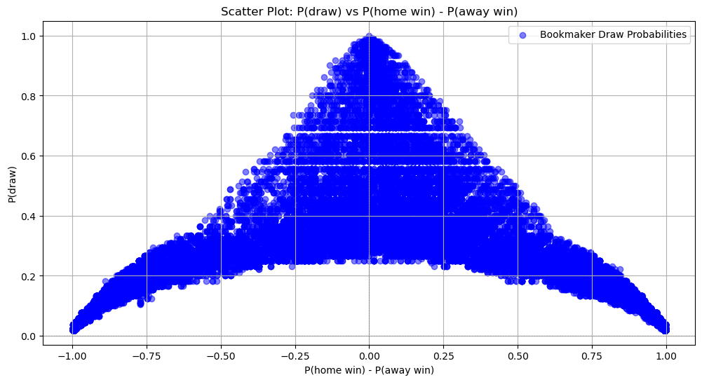

```python
import matplotlib.pyplot as plt

# Scatter Plot: P(draw) vs P(home win) - P(away win)
plt.figure(figsize=(12, 6))
plt.scatter(clean_data['Home_Away_Diff'], clean_data['P_draw'], color='blue', alpha=0.5, label='Bookmaker Draw Probabilities')

# Enhance Plot
plt.axhline(0, color='gray', linestyle='--', linewidth=0.5)
plt.axvline(0, color='gray', linestyle='--', linewidth=0.5)
plt.xlabel('P(home win) - P(away win)')
plt.ylabel('P(draw)')
plt.title('Scatter Plot: P(draw) vs P(home win) - P(away win)')
plt.legend()
plt.grid()
plt.show()
```

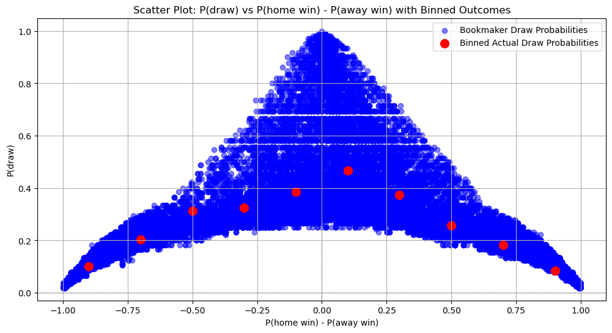

```python
# Calculate midpoints for bins if not already done
bin_analysis['Bin_Midpoint'] = bin_analysis['Bins'].apply(lambda x: (x.left + x.right) / 2)

# Scatter Plot: P(draw) vs P(home win) - P(away win) with Binned Outcomes
plt.figure(figsize=(12, 6))

# Original bookmaker probabilities
plt.scatter(clean_data['Home_Away_Diff'], clean_data['P_draw'], color='blue', alpha=0.5, label='Bookmaker Draw Probabilities')

# Binned outcomes: Actual draw probabilities
plt.scatter(bin_analysis['Bin_Midpoint'], bin_analysis['Actual_Draw_Rate'], color='red', label='Binned Actual Draw Probabilities', s=100)

# Enhance Plot
plt.axhline(0, color='gray', linestyle='--', linewidth=0.5)
plt.axvline(0, color='gray', linestyle='--', linewidth=0.5)
plt.xlabel('P(home win) - P(away win)')
plt.ylabel('P(draw)')
plt.title('Scatter Plot: P(draw) vs P(home win) - P(away win) with Binned Outcomes')
plt.legend()
plt.grid()
plt.show()
```

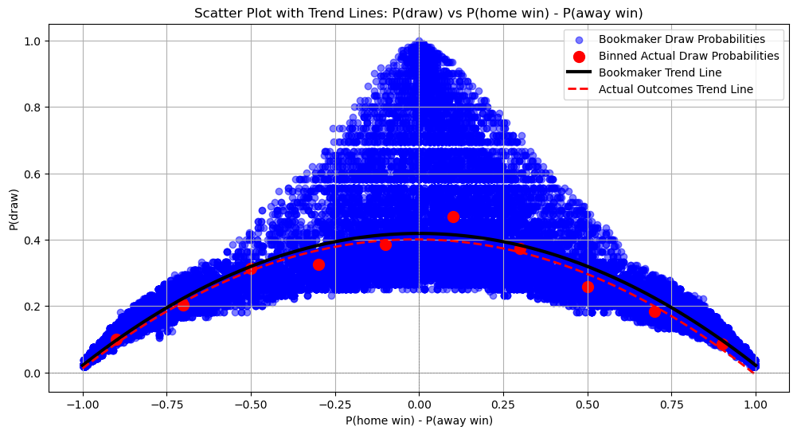

```python
import numpy as np
from numpy.polynomial.polynomial import Polynomial

# Step 1: Fit a polynomial trend line for bookmaker probabilities
bookmaker_trend = Polynomial.fit(clean_data['Home_Away_Diff'], clean_data['P_draw'], deg=2)

# Generate predictions for bookmaker trend line
x_vals = np.linspace(-1, 1, 100)  # X-axis range for smooth trend line
bookmaker_y_vals = bookmaker_trend(x_vals)  # Polynomial predictions for bookmaker

# Step 2: Fit a polynomial trend line for binned actual probabilities
actual_trend = Polynomial.fit(bin_analysis['Bin_Midpoint'], bin_analysis['Actual_Draw_Rate'], deg=2)

# Generate predictions for actual outcomes trend line
actual_y_vals = actual_trend(x_vals)

# Step 3: Plot scatter plot and trend lines
plt.figure(figsize=(12, 6))

# Scatter plot for bookmaker probabilities
plt.scatter(clean_data['Home_Away_Diff'], clean_data['P_draw'], color='blue', alpha=0.5, label='Bookmaker Draw Probabilities')

# Binned outcomes scatter points
plt.scatter(bin_analysis['Bin_Midpoint'], bin_analysis['Actual_Draw_Rate'], color='red', label='Binned Actual Draw Probabilities', s=100)

# Bookmaker trend line
plt.plot(x_vals, bookmaker_y_vals, color='black', linestyle='-', linewidth=3, label='Bookmaker Trend Line')  # Adjusted to black and thicker

# Actual outcomes trend line
plt.plot(x_vals, actual_y_vals, color='red', linestyle='--', linewidth=2, label='Actual Outcomes Trend Line')

# Enhance plot
plt.axhline(0, color='gray', linestyle='--', linewidth=0.5)
plt.axvline(0, color='gray', linestyle='--', linewidth=0.5)
plt.xlabel('P(home win) - P(away win)')
plt.ylabel('P(draw)')
plt.title('Scatter Plot with Trend Lines: P(draw) vs P(home win) - P(away win)')
plt.legend()
plt.grid()
plt.show()
```

**Task 1 Data Interpretation**

As we can observe from the last Scatter Plot with Trend Lines: P(draw) vs P(home win) - P(away win) graph,

The graph visualizes the relationship between the difference in probabilities for a home win and an away win (P(home win) - P(away win)) on the x-axis and the probability of a draw (P(draw)) on the y-axis. Blue dots represent bookmaker-provided draw probabilities (P(draw)) for individual matches. These dots scatter around the bookmaker trend line and show how the draw probabilities vary as the difference between P(home win) and P(away win) changes. When P(home win) - P(away win) is close to 0, the draw probability is higher because teams are perceived to be evenly matched. Red dots represent binned actual draw probabilities, calculated based on the actual outcomes in different bins. These red dots aggregate the outcomes into bins, showing the observed probability of a draw for matches in each bin. This allows us to compare actual outcomes with bookmaker probabilities. The black line reflects the bookmaker's trend in predicting draw probabilities across different game scenarios. The red dashed line represents actual outcomes and helps identify whether the bookmaker's predictions align with observed match results.

**Insights and Interpretation**

The bookmaker trend line and actual outcomes trend line are fairly close to each other, indicating that bookmaker predictions are relatively accurate in capturing the likelihood of draws.However, slight deviations suggest that there may be room for inefficiencies or discrepancies in certain match situations. When P(home win) - P(away win) is near 0 (balanced teams), both bookmaker predictions and actual outcomes show the highest probabilities of a draw. This aligns with intuition, as closely matched teams are more likely to draw. At the extremes of P(home win) - P(away win) (e.g., -1 or 1), the actual outcomes trend line sometimes deviates from the bookmaker line. This may suggest potential inefficiencies in how bookmakers account for one-sided matches and having bias. To sum up, the graph shows that bookmaker predictions for draws are generally aligned with observed results, especially for balanced matches. However, there are slight discrepancies at the extremes, indicating possible inefficiencies in the odds market. These inefficiencies could be explored further for betting strategies.

**TASK 2**

```python
# Determine matches with goals after the 90th minute
# If the 'minute' column is specified as 45+ or 90+, goal checks can be performed

# Filter rows corresponding to 90+ minutes
late_goals = clean_data[(clean_data['halftime'] == '2nd-half') & (clean_data['minute'] > 45)]

# Maç ID'lerini belirleme
late_goal_matches = late_goals['fixture_id'].unique()

print(f"Number of matches with goals in 90+ minutes: {len(late_goal_matches)}")
```

```
Number of matches with goals in 90+ minutes: 457
```

```python
# Filtering matches with red cards in the first 15 minutes
early_red_cards = clean_data[(clean_data['minute'] <= 15) &
                             ((clean_data['Redcards - away'] > 0) | (clean_data['Redcards - home'] > 0))]

# Determining match IDs
red_card_matches = early_red_cards['fixture_id'].unique()

print(f"Number of matches with red cards in the first 15 minutes: {len(red_card_matches)}")
```

```
Number of matches with red cards in the first 15 minutes: 100
```

```python
# Merging noisy match IDs
noise_matches = set(late_goal_matches).union(set(red_card_matches))

# Removing noisy matches from the dataset
clean_task2 = clean_data[~clean_data['fixture_id'].isin(noise_matches)].copy()

print(f"Matches containing noise were removed. Number of remaining matches: {clean_task2['fixture_id'].nunique()}")
```

```
Matches containing noise were removed. Number of remaining matches: 164
```

```python
print(clean_task2.describe())
```

```
         fixture_id        minute        second             1             2  \
count  1.238500e+04  12385.000000  12385.000000  12385.000000  12385.000000
mean   1.914791e+07     22.572547     28.288494     16.234836     28.218195
std    1.323232e+04     13.388908     18.303037     49.360402     67.094052
min    1.913445e+07      0.000000      0.000000      1.000000      1.000000
25%    1.913530e+07     11.000000     10.000000      1.140000      1.530000
50%    1.913974e+07     22.000000     29.000000      1.900000      4.500000
75%    1.915512e+07     34.000000     46.000000      7.000000     21.000000
max    1.917212e+07     55.000000     59.000000    501.000000    501.000000

                  X  Accurate Crosses - away  Accurate Crosses - home  \
count  12385.000000             12385.000000             12385.000000
mean      11.261124                 1.573510                 2.137354
std       12.498152                 1.626752                 2.034649
min        1.300000                 0.000000                 0.000000
25%        3.600000                 0.000000                 1.000000
50%        5.500000                 1.000000                 2.000000
75%       13.000000                 2.000000                 3.000000
max       51.000000                 9.000000                13.000000

       Assists - away  Assists - home  ...  Yellowcards - home  \
count    12385.000000    12385.000000  ...        12385.000000
mean         0.752940        0.845695  ...            0.585103
std          0.619299        0.650816  ...            0.850984
min          0.000000        0.000000  ...            0.000000
25%          0.000000        0.839712  ...            0.000000
50%          0.769807        0.839712  ...            0.000000
75%          1.000000        1.000000  ...            1.000000
max          4.000000        3.000000  ...            4.000000

       Yellowred Cards - away  Yellowred Cards - home    P_home_win  \
count            12385.000000            12385.000000  12385.000000
mean                 0.004574                0.002297      0.514288
std                  0.005621                0.002824      0.363177
min                  0.000000                0.000000      0.001996
25%                  0.000000                0.000000      0.142857
50%                  0.000000                0.000000      0.526316
75%                  0.011480                0.005768      0.877193
max                  0.011480                0.005768      1.000000

             P_draw    P_away_win  P_home_win_norm   P_draw_norm  \
count  12385.000000  12385.000000     12385.000000  12385.000000
mean       0.187619      0.357884         0.485856      0.176289
std        0.123024      0.348483         0.344988      0.115330
min        0.019608      0.001996         0.001945      0.019082
25%        0.076923      0.047619         0.133730      0.072374
50%        0.181818      0.222222         0.494214      0.171079
75%        0.277778      0.653595         0.828704      0.261283
max        0.769231      1.000000         0.978853      0.720000

       P_away_win_norm  Home_Away_Diff
count     12385.000000    12385.000000
mean          0.337855        0.156404
std           0.330520        0.702190
min           0.001917       -0.998004
25%           0.044595       -0.503609
50%           0.207629        0.302294
75%           0.618091        0.838731
max           0.978853        0.998004

[8 rows x 95 columns]
```

```python
# Calculate probabilities (P(home win), P(draw), P(away win))
clean_task2['P_home_win'] = 1 / clean_task2['1']  # Assuming column '1' represents home win odds
clean_task2['P_draw'] = 1 / clean_task2['X']      # Assuming column 'X' represents draw odds
clean_task2['P_away_win'] = 1 / clean_task2['2']  # Assuming column '2' represents away win odds

# Normalize probabilities
normalization_factor = clean_task2['P_home_win'] + clean_task2['P_draw'] + clean_task2['P_away_win']
clean_task2['P_home_win_norm'] = clean_task2['P_home_win'] / normalization_factor
clean_task2['P_draw_norm'] = clean_task2['P_draw'] / normalization_factor
clean_task2['P_away_win_norm'] = clean_task2['P_away_win'] / normalization_factor

# Calculate P(home win) - P(away win)
clean_task2['Home_Away_Diff'] = clean_task2['P_home_win'] - clean_task2['P_away_win']

# Bin P(home win) - P(away win) values
bins = np.linspace(-1, 1, 11)  # Define bins from -1 to 1 with 10 equal intervals
clean_task2['Bins'] = pd.cut(clean_task2['Home_Away_Diff'], bins=bins)

# Calculate actual draw probabilities for each bin
bin_analysis_task2 = clean_task2.groupby('Bins').apply(
    lambda x: pd.Series({
        'Bookmaker_Draw_Probability': x['P_draw'].mean(),
        'Actual_Draw_Rate': (x['result'] == 'X').mean()  # Assuming 'result' contains the actual outcome
    })
).reset_index()
```

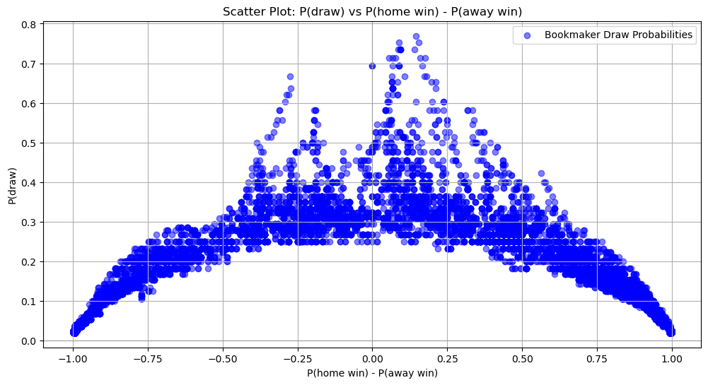

```python
import matplotlib.pyplot as plt

# Scatter Plot: P(draw) vs P(home win) - P(away win)
plt.figure(figsize=(12, 6))
plt.scatter(clean_task2['Home_Away_Diff'], clean_task2['P_draw'], color='blue', alpha=0.5, label='Bookmaker Draw Probabilities')

# Enhance Plot
plt.axhline(0, color='gray', linestyle='--', linewidth=0.5)
plt.axvline(0, color='gray', linestyle='--', linewidth=0.5)
plt.xlabel('P(home win) - P(away win)')
plt.ylabel('P(draw)')
plt.title('Scatter Plot: P(draw) vs P(home win) - P(away win)')
plt.legend()
plt.grid()
plt.show()
```

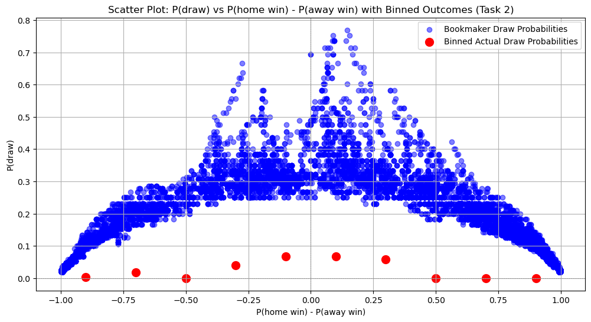

```python
# Calculate midpoints for bins if not already done
bin_analysis_task2['Bin_Midpoint'] = bin_analysis_task2['Bins'].apply(lambda x: (x.left + x.right) / 2)

# Scatter Plot: P(draw) vs P(home win) - P(away win) with Binned Outcomes
plt.figure(figsize=(12, 6))

# Original bookmaker probabilities
plt.scatter(clean_task2['Home_Away_Diff'], clean_task2['P_draw'], color='blue', alpha=0.5, label='Bookmaker Draw Probabilities')

# Binned outcomes: Actual draw probabilities
plt.scatter(bin_analysis_task2['Bin_Midpoint'], bin_analysis_task2['Actual_Draw_Rate'], color='red', label='Binned Actual Draw Probabilities', s=100)

# Enhance Plot
plt.axhline(0, color='gray', linestyle='--', linewidth=0.5)
plt.axvline(0, color='gray', linestyle='--', linewidth=0.5)
plt.xlabel('P(home win) - P(away win)')
plt.ylabel('P(draw)')
plt.title('Scatter Plot: P(draw) vs P(home win) - P(away win) with Binned Outcomes (Task 2)')
plt.legend()
plt.grid()
plt.show()
```

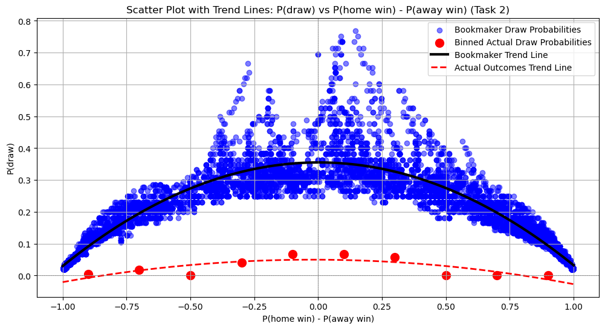

```python
import numpy as np
from numpy.polynomial.polynomial import Polynomial

# Step 1: Fit a polynomial trend line for bookmaker probabilities
bookmaker_trend_task2 = Polynomial.fit(clean_task2['Home_Away_Diff'], clean_task2['P_draw'], deg=2)

# Generate predictions for bookmaker trend line
x_vals_task2 = np.linspace(-1, 1, 100)  # X-axis range for smooth trend line
bookmaker_y_vals_task2 = bookmaker_trend_task2(x_vals_task2)  # Polynomial predictions for bookmaker

# Step 2: Fit a polynomial trend line for binned actual probabilities
actual_trend_task2 = Polynomial.fit(bin_analysis_task2['Bin_Midpoint'], bin_analysis_task2['Actual_Draw_Rate'], deg=2)

# Generate predictions for actual outcomes trend line
actual_y_vals_task2 = actual_trend_task2(x_vals_task2)

# Step 3: Plot scatter plot and trend lines
plt.figure(figsize=(12, 6))

# Scatter plot for bookmaker probabilities
plt.scatter(clean_task2['Home_Away_Diff'], clean_task2['P_draw'], color='blue', alpha=0.5, label='Bookmaker Draw Probabilities')

# Binned outcomes scatter points
plt.scatter(bin_analysis_task2['Bin_Midpoint'], bin_analysis_task2['Actual_Draw_Rate'], color='red', label='Binned Actual Draw Probabilities', s=100)

# Bookmaker trend line
plt.plot(x_vals_task2, bookmaker_y_vals_task2, color='black', linestyle='-', linewidth=3, label='Bookmaker Trend Line')  # Adjusted to black and thicker

# Actual outcomes trend line
plt.plot(x_vals_task2, actual_y_vals_task2, color='red', linestyle='--', linewidth=2, label='Actual Outcomes Trend Line')

# Enhance plot
plt.axhline(0, color='gray', linestyle='--', linewidth=0.5)
plt.axvline(0, color='gray', linestyle='--', linewidth=0.5)
plt.xlabel('P(home win) - P(away win)')
plt.ylabel('P(draw)')
plt.title('Scatter Plot with Trend Lines: P(draw) vs P(home win) - P(away win) (Task 2)')
plt.legend()
plt.grid()
plt.show()
```

**Task 2 Data Interpretation**